# Data Science 101

## What is Data Science

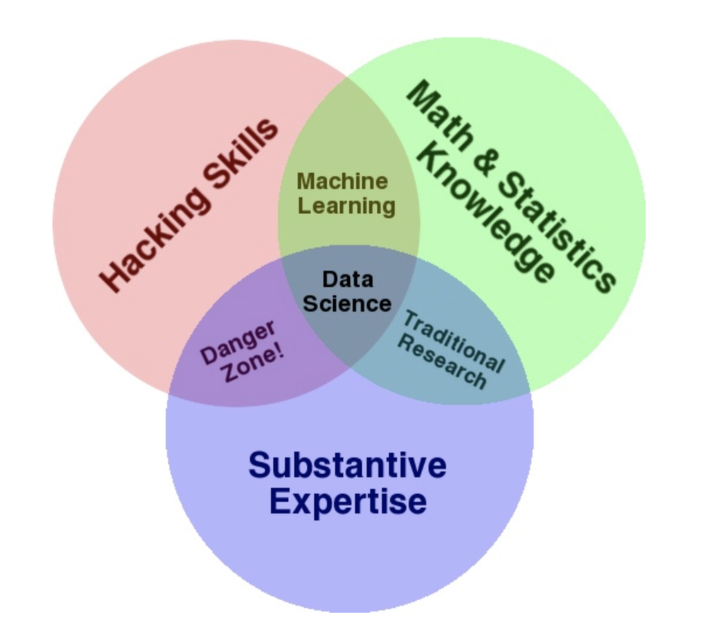

Drew Conway’s Venn Diagram of Data Science

## AI Framework

[figure not shown]

AI Framework

## Data Scientists Use Machine Learning

\[X=\mbox{Input}\] \[f(X)=\mbox{Do Something to Input}\]

\[y=\mbox{Observed Output}\]

\[y=f(X)+\epsilon\]

## Breaking This Down

\[y=f(X)+\epsilon\]

- \(y\) can be: Numbers or Categories
- \(X\) can be anything we can quantify
- \(f(X)\) is largely unknown but perhaps assumed/tested

```r
library(caret)
library(tidyverse)
data(OJ,package = "ISLR")
str(OJ)
```

```
## 'data.frame':    1070 obs. of  18 variables:
##  $ Purchase      : Factor w/ 2 levels "CH","MM": 1 1 1 2 1 1 1 1 1 1 ...
##  $ WeekofPurchase: num  237 239 245 227 228 230 232 234 235 238 ...
##  $ StoreID       : num  1 1 1 1 7 7 7 7 7 7 ...
##  $ PriceCH       : num  1.75 1.75 1.86 1.69 1.69 1.69 1.69 1.75 1.75 1.75 ...
##  $ PriceMM       : num  1.99 1.99 2.09 1.69 1.69 1.99 1.99 1.99 1.99 1.99 ...
##  $ DiscCH        : num  0 0 0.17 0 0 0 0 0 0 0 ...
##  $ DiscMM        : num  0 0.3 0 0 0 0 0.4 0.4 0.4 0.4 ...
##  $ SpecialCH     : num  0 0 0 0 0 0 1 1 0 0 ...
##  $ SpecialMM     : num  0 1 0 0 0 1 1 0 0 0 ...
##  $ LoyalCH       : num  0.5 0.6 0.68 0.4 0.957 ...
##  $ SalePriceMM   : num  1.99 1.69 2.09 1.69 1.69 1.99 1.59 1.59 1.59 1.59 ...
##  $ SalePriceCH   : num  1.75 1.75 1.69 1.69 1.69 1.69 1.69 1.75 1.75 1.75 ...
##  $ PriceDiff     : num  0.24 -0.06 0.4 0 0 0.3 -0.1 -0.16 -0.16 -0.16 ...
##  $ Store7        : Factor w/ 2 levels "No","Yes": 1 1 1 1 2 2 2 2 2 2 ...
##  $ PctDiscMM     : num  0 0.151 0 0 0 ...
##  $ PctDiscCH     : num  0 0 0.0914 0 0 ...
##  $ ListPriceDiff : num  0.24 0.24 0.23 0 0 0.3 0.3 0.24 0.24 0.24 ...
##  $ STORE         : num  1 1 1 1 0 0 0 0 0 0 ...
```

## Evaluating Model

- \(y\) is a number \(\sum(\hat{y}-y)^2\)
- \(y\) is a category, cross-entropy, accuracy, etc.
- Train/Test Split

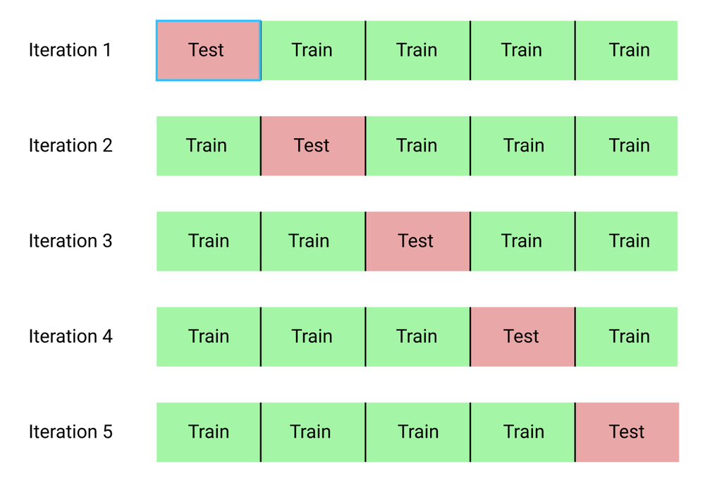

5 Fold CV

## Building a Simple Classification Model

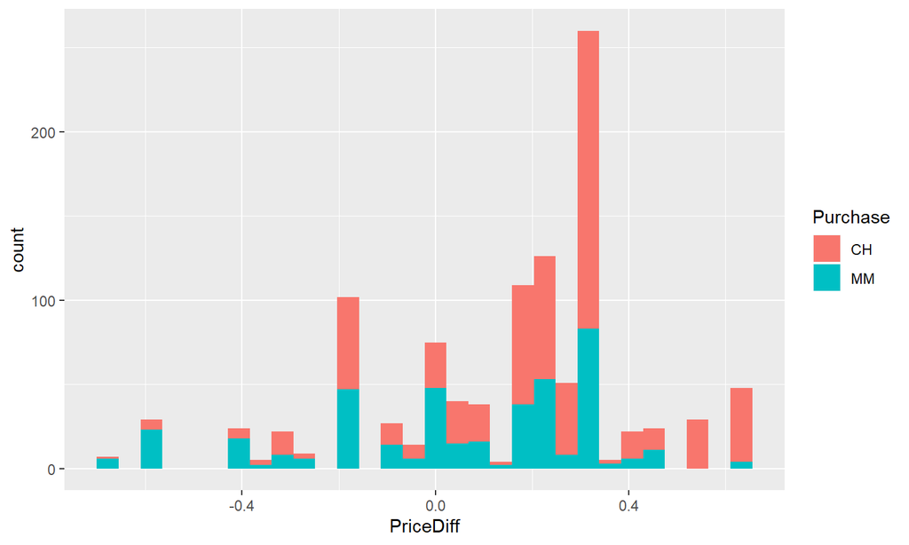

```r
OJ %>% ggplot(aes(x=PriceDiff,fill=Purchase))+geom_histogram()
```

```r
OJ <- OJ %>% select(- PctDiscCH,-PctDiscMM,-StoreID,-STORE,-SalePriceMM,-SalePriceCH,-PriceCH,-PriceMM,-ListPriceDiff)
```

## Naive Model

- Gotta beat this…
- \(f(X)= \mbox{CH if CH is Cheaper, else MM}\)

```r
OJ.mod<-OJ%>%mutate(Cheap=ifelse(PriceDiff>0,"CH","MM"))
sum(OJ.mod$Purchase==OJ.mod$Cheap)/nrow(OJ.mod)
```

```
## [1] 0.6495327
```

## Logistic Regression - Blocking and Tackling

- Moderately Interpretable
- Not controversial
- Must a-priori choose features

## Model Building/Testing

```r
set.seed(430)
default_idx = createDataPartition(OJ$Purchase, p = 0.75, list = FALSE)
default_trn = OJ[default_idx, ]
default_tst = OJ[-default_idx, ]

default_glm_mod = train(
  form = Purchase ~ .,
  data = default_trn,
  trControl = trainControl(method = "cv", number = 5),
  method = "glm",
  family = "binomial"
)
```

## Logistic Regression

```r
default_glm_mod$results
```

```
##   parameter  Accuracy    Kappa AccuracySD    KappaSD
## 1      none 0.8256599 0.629836 0.02819943 0.05863423
```

```r
default_glm_mod$finalModel
```

```
##
## Call:  NULL
##
## Coefficients:
##    (Intercept)  WeekofPurchase          DiscCH          DiscMM       SpecialCH
##       2.824872        0.001716       -0.455065        0.087416        0.054433
##      SpecialMM         LoyalCH       PriceDiff       Store7Yes
##       0.112112       -6.149198       -2.661150       -0.560337
##
## Degrees of Freedom: 802 Total (i.e. Null);  794 Residual
## Null Deviance:       1074
## Residual Deviance: 640.6     AIC: 658.6
```

## \(f(x)\) Structure

- In first example very basic
- Second Example:

\[p(MM)=\frac{\exp(X^T \beta)}{1+\exp(X^T \beta)}\]

## Out of Sample Testing

```r
default_tst_pred <- predict(default_glm_mod, default_tst, type = "prob")

default_tst_pred$Purchase <- ifelse(default_tst_pred$CH>0.5,"CH","MM")
pred.tab<-table(predicted = default_tst_pred$Purchase, actual = default_tst$Purchase)
#pred.tab
(pred.tab[1,1]+pred.tab[2,2])/sum(pred.tab)
```

```
## [1] 0.8576779
```

## Other Structures

## Trees

- Intepretable
- Split on Features that maximize Gini Index
- Not really that good, but form the basis for other predictive methods

## Tree

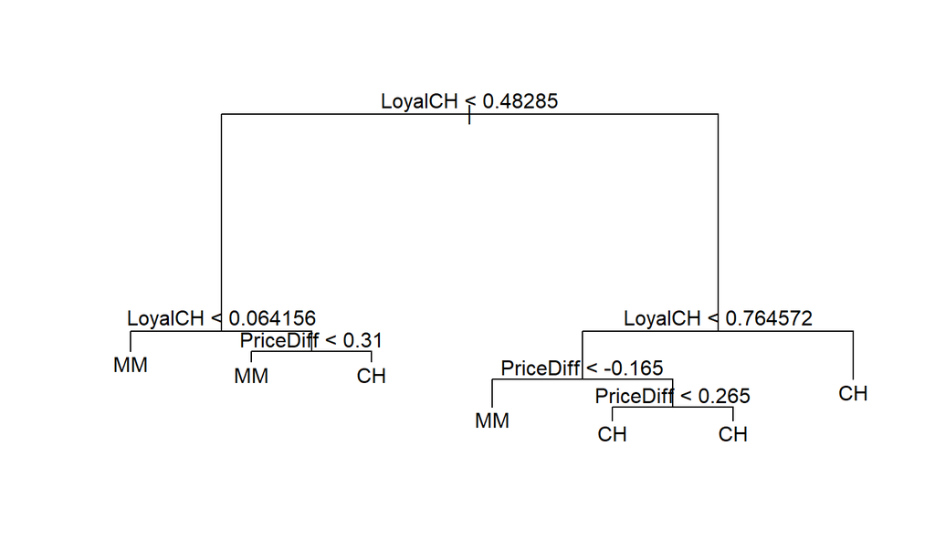

## Tree

```r
ctrl <- trainControl(method = "repeatedcv",
                     number = 10,
                     repeats = 3)
test_tree<-train(Purchase~.,data=default_trn,
               method = "rpart",
               trControl = ctrl)
default_tst_pred <- predict(test_tree, default_tst, type = "prob")
default_tst_pred$Purchase<-ifelse(default_tst_pred$CH>.5,"CH","MM")
pred.tab<-table(predicted = default_tst_pred$Purchase, actual = default_tst$Purchase)
#pred.tab
(pred.tab[1,1]+pred.tab[2,2])/sum(pred.tab)
```

```
## [1] 0.8052434
```

## LDA

- Assume distribution for each class
- Find how likely it is that the new data comes from each class, classify to highest probability
- For two classes gives similar/same results as Logistic Regression

```r
lda.fit <- train(Purchase ~ ., data=default_trn, method="lda")
```

## LDA Fit

```r
lda.pred <- predict(lda.fit, default_tst,type="prob")
lda.pred$Purchase<-ifelse(lda.pred$CH>0.5,"CH","MM")
pred.tab<-table(lda.pred$Purchase, default_tst$Purchase)
#pred.tab
(pred.tab[1,1]+pred.tab[2,2])/sum(pred.tab)
```

```
## [1] 0.8576779
```

## Bagging Algorithms

- Take many training sets from population
- Build seperate prediction models using each training set
- Average the resulting predictions

\[ \hat{f}(x)= \frac{1}{B} \sum_{b=1} \hat{f}^b(x)\] - Random Forest is most popular

## Random Forest

```r
control <- trainControl(method="repeatedcv", number=10, repeats=3)
metric <- "Accuracy"
mtry <- sqrt(ncol(default_trn)-1)
tunegrid <- expand.grid(.mtry=mtry)
rf_default <- train(Purchase~., data=default_trn, method="rf", metric=metric, tuneGrid=tunegrid, trControl=control)
rf.pred <- predict(rf_default, default_tst,type="prob")
rf.pred$Purchase<-ifelse(rf.pred$CH>0.5,"CH","MM")
pred.tab<-table(rf.pred$Purchase, default_tst$Purchase)
#pred.tab
(pred.tab[1,1]+pred.tab[2,2])/sum(pred.tab)
```

```
## [1] 0.8127341
```

## Boosting Algorithms

- Combine a bunch of weak learners to make a strong learner
- Built sequentially by fitting trees to residuals
- Requires multiple tuning parameters (user supplied information)
- AdaBoost is most popular

## AdaBoost

```r
fitGrid_2 <- expand.grid(mfinal = (1:3)*3,
                         maxdepth = c(1, 3),
                         coeflearn = c("Breiman"))

fitControl_2 <- trainControl(method = "repeatedcv",
                             number = 2,
                             repeats = 1)
ada.fit <- train(Purchase ~ ., data=default_trn, method="AdaBoost.M1", trControl = fitControl_2,
  tuneGrid = fitGrid_2)

ada.pred <- predict(ada.fit, default_tst)
pred.tab<-table(ada.pred, default_tst$Purchase)
#pred.tab
(pred.tab[1,1]+pred.tab[2,2])/sum(pred.tab)
```

```
## [1] 0.82397
```

## Artificial Neural Networks

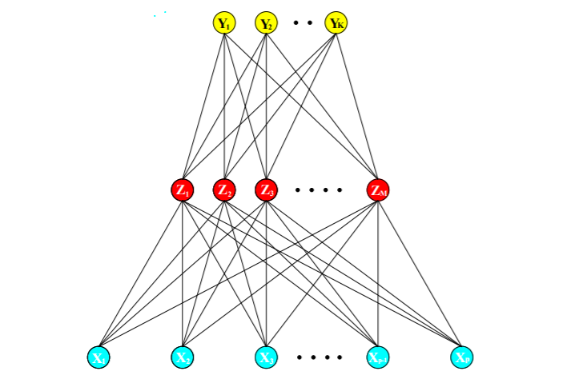

Neural Network

- Requires a ton of tuning/user input
- Can be shown that there exists NN to exactly approximate ``true" \(f(x)\)

## Other \(X\) Options

- Image

```
## # A tibble: 1 x 7
##   format width height colorspace matte filesize density
##   <chr>  <int>  <int> <chr>      <lgl>    <int> <chr>
## 1 PNG      350    350 sRGB       TRUE         0 72x72
```

[figure not shown]

```r
library(magick)

tiger <- image_read_svg('http://jeroen.github.io/images/tiger.svg', width = 350)
print(tiger)
```

## Images

```r
class(as.numeric(tiger[[1]]))
```

```
## [1] "array"
```

```r
dim(as.numeric(tiger[[1]]))
```

```
## [1] 350 350   4
```

## \(f(X)\) of Images

- Often convolutions of kernels

```r
kern <- matrix(0, ncol = 3, nrow = 3)
kern[1, 2] <- 0.25
kern[2, c(1, 3)] <- 0.25
kern[3, 2] <- 0.25
kern
```

```
##      [,1] [,2] [,3]
## [1,] 0.00 0.25 0.00
## [2,] 0.25 0.00 0.25
## [3,] 0.00 0.25 0.00
```

## \(f(X)\) of Images

[figure not shown]

```r
img_blurred <- image_convolve(tiger, kern)
image_append(c(tiger, img_blurred))
```

## Other Kernels

[figure not shown]

```r
kern2 <- matrix(0, ncol = 3, nrow = 3)
kern2[c(1,3), 1] <- 1
kern2[2, 1] <- 2
kern2[c(1,3),3] <- -1
kern2[2,3]<- -2
img_sobel <- image_convolve(tiger, kern2)
img_sobel
```

## \(y=f(X)+\epsilon\)

- \(X\) is anything that can be represented by a number - Factors, Images, Words
- \(y\) is a number - Regression framework
- \(y\) is one of several factors (good, bad, ugly) - One hot encoding
- Data availability for \(X\) and \(y\) determine choices for technique
- Many off-the-shelt techniques require tuning/user input
- Interpretability vs Prediction

## Data Science Done Wrong

## Errors

Types of Errors:  
- Question Errors  
- Interpretation Errors  
- Process Errors  
- Application Errors

Patrick Surry and Nick Radcliffe

## Question Errors

[figure not shown]

- Correct/properly scoped question
- Failure to include required constraints

## Interpretation Errors

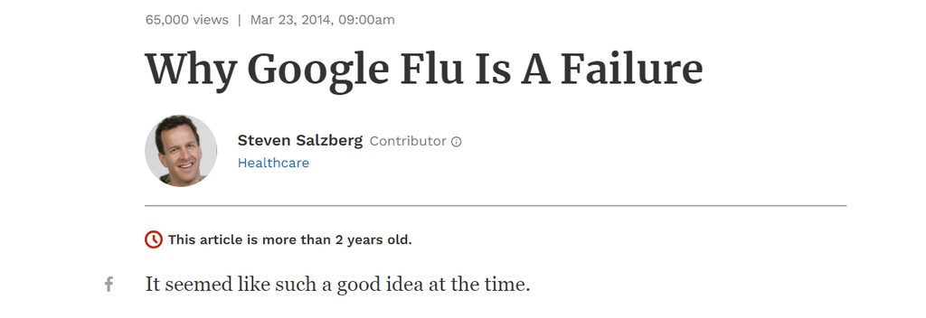

- Data must be accurate
- Data must mean what you think it means

## Process Errors

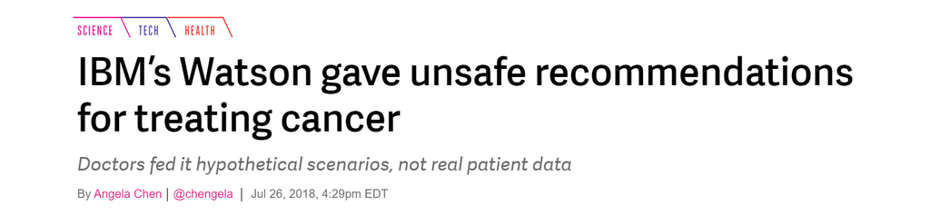

- Model and method assumptions must be validated.
- Shortcuts don’t usually pay off

## Application Errors

[figure not shown]

- Overfitting of training data
- Misunderstanding of methodology

## Biases

Types of Bias:  
- Sample Bias  
- Exclusion Bias  
- Observer Bias  
- Confounding Bias  
- Measurement Bias

Salma Ghoneim / Catalogue of Bias

## Sample Bias

- Issue:
  - Data used for building the model doesn’t represent the operational environment
- Population vs. Sample
- Fix:
  - Choose a representative sample
  - Unbiased sampling method
  - Large enough sample size
- Rare events

## Exclusion Bias

- Issue:
  - Removing potentially important features in the name of “cleaning”
- Fix:
  - Clean only what’s necessary
  - Fully understand features

## Observer Bias

- Issue:
  - We tend to see what we expect to see
- Fix:
  - Procedures for data collection and handling
  - Intellectual honesty

## Confounding Bias

- Issue:
  - Suggesting an association where there is none or masking a true association
- Nightlight vs. Myopia
- Fix:
  - Random assignment
  - Complete consideration of features

## Measurement Bias

- Issue:
  - Device(s) used for measurement alter data in some way
- Fix:
  - Understand data collection mechanisms
  - Multiple measuring devices
  - Training on the use of devices

## Current Research that May be of Interest

## Early Warning Project

- Identifying historical episodes of state- and non-state-led mass killing
- Compiling data of potential “predictors” or “risk factors”
- Training different statistical algorithms on historical data (1945 to 2015) to identify a model that performs well predicting onset of mass killing within the training set
- Testing alternative models and selecting one that maximizes accuracy
- Logistic Regression with Elastic Net regularizing (30 Variables)
- In R this can be done `model<-glmnet(x,y,family="binomial",alpha=value)`

## Early Warning Project

- Results indicate that eight out of every ten countries that later experienced a new onset of mass killing had risk estimates of greater than 4 percent
- Afghanistan, Yemen, Pakistan, S. Sudan, Congo, Egypt, Sudan, Somalia, Cameroon, Ethiopia
- Early warning project, https://earlywarningproject.ushmm.org/

## Bayesian Hierarchical Model for Criminal Investigations

- Framework for assessing probability of attacks

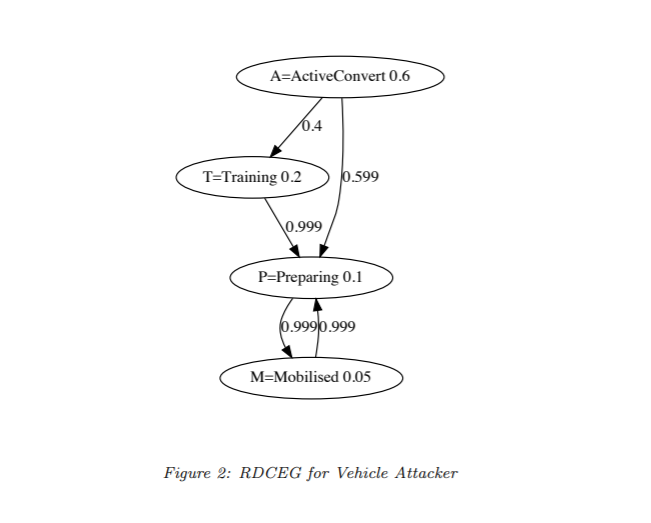

- Based off of observed intel, probability of being in given state
- A Bayesian Hierarchical Model for Criminal Investigations, 2019 - Bunnin, Smith

## Crime Predictions (DOJ Sponsored)

- Winning Entry

\[ P_j(\tau,m)= \alpha + \sum_{i:c_i=j} h_{m,m_i}(t-t_i; \beta)\] - Locations where crimes occur have short term probability of future crimes occuring in same location or nearby

- Self-Exciting Point Processes
- Rotational grid, PAI-maximizing crime forecasts, 2018 - Mohler, Porter

## Some Things we have Done

- Automated Feature Extraction for GEOINT - Neural Networks to automatically classify pixels
- Predicting success of RASP for Regimental Psych
- Bayesian Reliability for Long Range Precision Fires
- Evaluating NAG surveys
- Counter UAS metrics

## Some Recommendations

- What question are you trying to answer?
- How is this measured?
- What data have you collected to support that decision making process?
- What can serve as a proxy if data is not available?
- What decisions are you making?
- Until these questions are answered, data science can do little to help